# 3a Prova d’Avaluació Contínua (PAC3)

Programari per a l’anàlisi de dades

Robert Buj

20/05/2026

# Secció 1. Models de classificació i validació (4,5 punts)

## Exercici 1. (2,25 punts)

El conjunt de dades Breast Cancer Wisconsin, inclòs al paquet mlbench d’R, és un dataset clàssic de classificació supervisada utilitzat per predir si un tumor mamari és benigne o maligne a partir de diverses caracteristiques observades en mostres cel·lulars. Aquestes característiques descriuen aspectes morfològics de les cèl·lules extretes mitjançant una biòpsia per aspiració amb agulla fina del teixit mamari.

Cada fila del dataset representa una mostra clínica d’una pacient, i les columnes recullen variables que mesuren propietats de les cèl·lules, com ara el gruix del grup cel·lular, la uniformitat de la mida i de la forma de les cèl·lules, l’adhesió marginal, la mida de les cèl·lules epitelials simples, la mida dels nuclis nus, la cromatina, els nuclèols normals i el nombre de mitosis. La variable resposta és `Class`, que indica el diagnòstic final: benigne o maligne.

A partir d’aquest conjunt, es demana:

1. (0.25 punts) Carregueu el conjunt de dades i realitzeu una exploració inicial (resum de variables, identificació de valors perduts i tractaments aplicats, etc.
2. (0.5 punts) Dividiu el conjunt de dades en dos subconjunts:
   1. Conjunt 1: Conjunt d’entrenament (70%)
   2. Conjunt 2: Conjunt de test (30%) Cal indicar breument el procediment utilitzat per fer aquesta partició.
3. (0.5 punts) Genereu un model de classificació amb el conjunt d’entrenament
   1. Ajusteu un model per predir la variable Class.
   2. Indiqueu quin model heu utilitzat i justifiqueu breument la tria.
4. (0.5 punts) Valideu el model amb el conjunt de test:
   1. Obtingueu la matriu de confusió.
   2. Calculeu les mètriques següents: accuracy - sensibilitat - especificitat - F1-score
   3. Interpreteu de forma crítica els resultats obtinguts.
5. (0.5 punts) Compareu l’accuracy del model amb una estratègia baseline. La baseline consisteix a ignorar totes les variables predictives i assignar sempre a tots els casos la classe que apareix més vegades al conjunt d’entrenament. En aquest dataset la classe majoritària és bening. Per tant, la baseline seria:

$$\text{Accuracy}_{\text{baseline}} = \frac{\text{Nombre de casos realment
benign}}{\text{Total de casos}}$$

**Resposta:**

```r
# Carreguem el dataset BreastCancer del paquet mlbench
data("BreastCancer", package = "mlbench")

# Exploració inicial del dataset
summary(BreastCancer)
```

```
##       Id             Cl.thickness   Cell.size     Cell.shape  Marg.adhesion
##  Length:699         1      :145   1      :384   1      :353   1      :407
##  Class :character   5      :130   10     : 67   2      : 59   2      : 58
##  Mode  :character   3      :108   3      : 52   10     : 58   3      : 58
##                     4      : 80   2      : 45   3      : 56   10     : 55
##                     10     : 69   4      : 40   4      : 44   4      : 33
##                     2      : 50   5      : 30   5      : 34   8      : 25
##                     (Other):117   (Other): 81   (Other): 95   (Other): 63
##   Epith.c.size  Bare.nuclei   Bl.cromatin  Normal.nucleoli    Mitoses
##  2      :386   1      :402   2      :166   1      :443     1      :579
##  3      : 72   10     :132   3      :165   10     : 61     2      : 35
##  4      : 48   2      : 30   1      :152   3      : 44     3      : 33
##  1      : 47   5      : 30   7      : 73   2      : 36     10     : 14
##  6      : 41   3      : 28   4      : 40   8      : 24     4      : 12
##  5      : 39   (Other): 61   5      : 34   6      : 22     7      :  9
##  (Other): 66   NA's   : 16   (Other): 69   (Other): 69     (Other): 17
##        Class
##  benign   :458
##  malignant:241
##
##
##
##
##
```

```r
# Identificació de valors perduts
sapply(BreastCancer, function(x) sum(is.na(x)))
```

```
##              Id    Cl.thickness       Cell.size      Cell.shape   Marg.adhesion
##               0               0               0               0               0
##    Epith.c.size     Bare.nuclei     Bl.cromatin Normal.nucleoli         Mitoses
##               0              16               0               0               0
##           Class
##               0
```

```r
# Eliminem les files amb valors perduts
bc <- BreastCancer[!is.na(BreastCancer$Bare.nuclei), ]

# Eliminem la variable ID, ja que no és útil per a la classificació
bc <- bc |> select(-Id)

# Tipus de dades de les variables
str(bc)
```

```
## 'data.frame':    683 obs. of  10 variables:
##  $ Cl.thickness   : Ord.factor w/ 10 levels "1"<"2"<"3"<"4"<..: 5 5 3 6 4 8 1 2 2 4 ...
##  $ Cell.size      : Ord.factor w/ 10 levels "1"<"2"<"3"<"4"<..: 1 4 1 8 1 10 1 1 1 2 ...
##  $ Cell.shape     : Ord.factor w/ 10 levels "1"<"2"<"3"<"4"<..: 1 4 1 8 1 10 1 2 1 1 ...
##  $ Marg.adhesion  : Ord.factor w/ 10 levels "1"<"2"<"3"<"4"<..: 1 5 1 1 3 8 1 1 1 1 ...
##  $ Epith.c.size   : Ord.factor w/ 10 levels "1"<"2"<"3"<"4"<..: 2 7 2 3 2 7 2 2 2 2 ...
##  $ Bare.nuclei    : Factor w/ 10 levels "1","2","3","4",..: 1 10 2 4 1 10 10 1 1 1 ...
##  $ Bl.cromatin    : Factor w/ 10 levels "1","2","3","4",..: 3 3 3 3 3 9 3 3 1 2 ...
##  $ Normal.nucleoli: Factor w/ 10 levels "1","2","3","4",..: 1 2 1 7 1 7 1 1 1 1 ...
##  $ Mitoses        : Factor w/ 9 levels "1","2","3","4",..: 1 1 1 1 1 1 1 1 5 1 ...
##  $ Class          : Factor w/ 2 levels "benign","malignant": 1 1 1 1 1 2 1 1 1 1 ...
```

```r
# Convertim les variables numèriques a tipus numèric
num_vars <- c(
    "Cl.thickness",
    "Cell.size",
    "Cell.shape",
    "Marg.adhesion",
    "Epith.c.size",
    "Bare.nuclei",
    "Bl.cromatin",
    "Normal.nucleoli",
    "Mitoses"
)
bc[num_vars] <- lapply(bc[num_vars], function(x) as.numeric(as.character(x)))

# Nombre de files i columnes després de tractar els valors perduts
dim(bc)
```

```
## [1] 683  10
```

```r
# Establim una llavor per a la reproductibilitat de la partició
set.seed(123)
# Dividim el dataset en entrenament (70%) i test (30%) amb mostreig estratificat
split <- sample.split(bc$Class, SplitRatio = 0.7)
data_train <- bc[split, ] # conjunt de dades d'entrenament
data_test <- bc[!split, ] # conjunt de dades de prova
```

S’ha utilitzat una funció de mostreig estratificat, sample.split de [caTools](https://www.rdocumentation.org/packages/caTools/), per dividir el dataset en un 70% per a entrenament i un 30% per a prova, mantenint la proporció de classes en ambdós subconjunts.

```r
# Ajustem un model de classificació SVM al conjunt d'entrenament
model <- svm(Class ~ ., data = data_train)
```

En aquest cas, per al model d’aprenentatge supervisat s’ha optat per SVM (Support Vector Machine), que és un model de classificació potent i versàtil, especialment adequat per a problemes amb múltiples característiques numèriques.

```r
# Realitzem prediccions en el conjunt de prova
predictions <- predict(model, newdata = data_test)
# Obtenim la matriu de confusió i les mètriques d'avaluació
confusion_matrix <- confusionMatrix(predictions, data_test$Class)
# Mostrem la matriu de confusió
confusion_matrix
```

```
## Confusion Matrix and Statistics
##
##            Reference
## Prediction  benign malignant
##   benign       129         3
##   malignant      4        69
##
##                Accuracy : 0.9659
##                  95% CI : (0.9309, 0.9862)
##     No Information Rate : 0.6488
##     P-Value [Acc > NIR] : <2e-16
##
##                   Kappa : 0.9253
##
##  Mcnemar's Test P-Value : 1
##
##             Sensitivity : 0.9699
##             Specificity : 0.9583
##          Pos Pred Value : 0.9773
##          Neg Pred Value : 0.9452
##              Prevalence : 0.6488
##          Detection Rate : 0.6293
##    Detection Prevalence : 0.6439
##       Balanced Accuracy : 0.9641
##
##        'Positive' Class : benign
##
```

```r
# F1-score
f1_score <- confusion_matrix$byClass["F1"]
f1_score
```

```
##        F1
## 0.9735849
```

L’exactitud del 0.9659 indica que el model té un rendiment excel·lent en la classificació de les mostres de test.

$$\text{Accuracy} = \frac{TP + TN}{TP + TN + FP + FN}
= \frac{69 + 129}{69 + 129 + 3 + 4}
= \frac{198}{205}
= 0.9659$$

L’$\text{AUC-ROC} \ge 0.9$, per tant el model discrimina de manera excepcional. La corba ROC gairebé és un triangle recte, indicant que el model té una capacitat excel·lent per diferenciar entre les classes benignes i malignes, amb molt pocs falsos positius i falsos negatius.

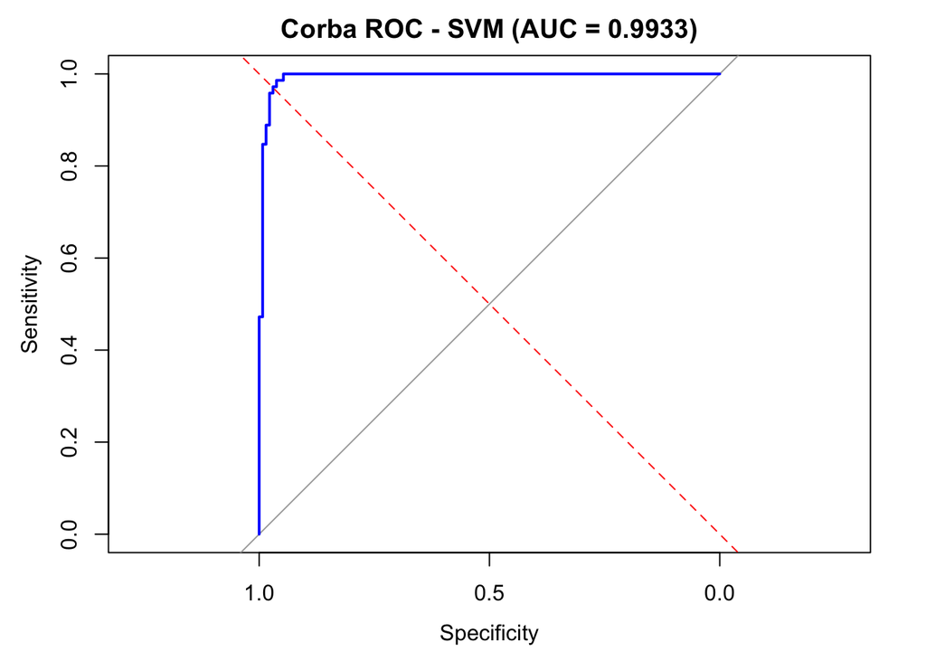

```r
# Entrenem el model amb probabilitats per a l'anàlisi de l'AUC-ROC
model <- svm(Class ~ ., data = data_train, probability = TRUE)
# Prediccions amb probabilitats
pred <- predict(model, newdata = data_test, probability = TRUE)
prob_predictions <- attr(pred, "probabilities")
# Càlcul de l'AUC-ROC
roc_obj <- roc(data_test$Class, prob_predictions[, "malignant"])
auc_value <- auc(roc_obj)
# Gràfic ROC
plot(
    roc_obj,
    main = sprintf("Corba ROC - SVM (AUC = %.4f)", auc_value),
    col = "blue"
)
abline(a = 0, b = 1, col = "red", lty = 2)
```

Si comparem l’exactitud del model amb una estratègia baseline, on es classifica sempre com a benigne (la classe majoritària al conjunt d’entrenament), obtenim:

```r
baseline_accuracy <- mean(data_test$Class == "benign")
baseline_accuracy
```

```
## [1] 0.6487805
```

$$\text{Accuracy}_{\text{baseline}} = \frac{TP + FN}{TP + TN + FP + FN}
= \frac{129 + 4}{129 + 69 + 3 + 4}
= \frac{133}{205} = 0.6488$$

$$\frac{\text{Accuracy}_{\text{SVM}} -
\text{Accuracy}_{\text{baseline}}}{\text{Accuracy}_{\text{baseline}}}
= \frac{0.9659 - 0.6488}{0.6488} \approx 0.5$$

## Exercici 2 (2,25 punts)

Durant un estudi de camp, uns investigadors van mesurar la humitat del sòl (en percentatge) sota diferents tipus de coberta vegetal en una zona protegida. Es van considerar quatre tipus de cobertes:

- H1: herba baixa
- H2: arbusts
- H3: arbrat aclarit
- H4: bosc dens

Per a cada tipus de coberta, es van fer 6 mostres en punts diferents. Els valors enregistrats van ser: - H1: 28, 33, 30, 27, 31, 28 - H2: 35, 37, 36, 38, 34, 33 - H3: 40, 39, 41, 42, 40, 43 - H4: 48, 46, 47, 45, 44, 48

Es demana:

1. (0.25 punts) Reformuleu les dades en un data.frame en format llarg (tidy data), de manera que hi hagi una columna numèrica amb la variable humitat i una columna de tipus factor amb la variable coberta. Cal mostrar l’estructura final del conjunt de dades.
2. (0.5 punts)Construïu amb ggplot2 un gràfic que permeti comparar la distribució de la humitat del sòl entre els diferents tipus de coberta. A continuació, interpreteu breument el gràfic i valoreu si, visualment, sembla que hi ha diferències entre grups.
3. (0.5 punts) Ajusteu un model ANOVA per estudiar si la humitat del sòl varia significativament segons el tipus de coberta vegetal. Caldrà especificar el model ajustat, els principals resultats obtinguts i interpretació d’aquests.
4. (0.5 punts) Si el resultat de l’ANOVA és significatiu, apliqueu una prova post-hoc de Tukey (Tukey HSD) per identificar entre quins grups hi ha diferències significatives.
5. (0.5 punts) Valideu els supòsits del model ANOVA mitjançant gràfics de residus i comenteu, de manera raonada, si els supòsits de normalitat i homogeneïtat de variàncies semblen acceptables.

**Resposta:**

Construcció del data.frame en format llarg:

```r
# Reformulem les dades en un data.frame en format llarg
H1_humitat <- c(28, 33, 30, 27, 31, 28)
H2_humitat <- c(35, 37, 36, 38, 34, 33)
H3_humitat <- c(40, 39, 41, 42, 40, 43)
H4_humitat <- c(48, 46, 47, 45, 44, 48)
data_df <- data.frame(
    humitat = c(H1_humitat, H2_humitat, H3_humitat, H4_humitat),
    coberta = factor(rep(c("H1", "H2", "H3", "H4"), each = 6))
)
# Mostrem l'estructura del conjunt de dades
str(data_df)
```

```
## 'data.frame':    24 obs. of  2 variables:
##  $ humitat: num  28 33 30 27 31 28 35 37 36 38 ...
##  $ coberta: Factor w/ 4 levels "H1","H2","H3",..: 1 1 1 1 1 1 2 2 2 2 ...
```

Distribució de la humitat del sòl entre els diferents tipus de coberta:

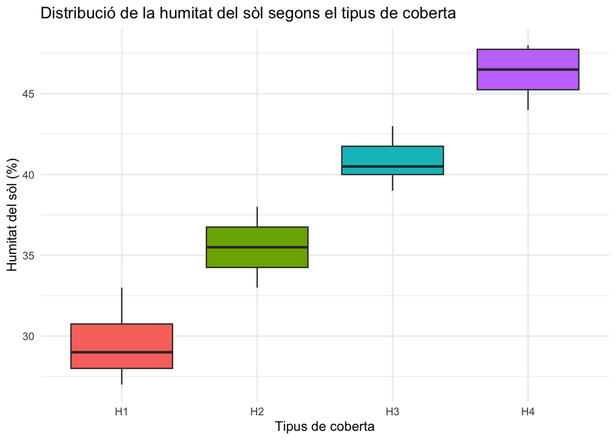

```r
# Construïm el gràfic amb ggplot2
ggplot(data_df, aes(x = coberta, y = humitat, fill = coberta)) +
    geom_boxplot() +
    labs(
        title = "Distribució de la humitat del sòl segons el tipus de coberta",
        x = "Tipus de coberta",
        y = "Humitat del sòl (%)"
    ) +
    theme_minimal() +
    theme(legend.position = "none")
```

Sembla que hi ha diferències en la humitat del sòl entre els diferents tipus de coberta. La humitat sembla augmentar progressivament des de l’herba baixa (H1) fins al bosc dens (H4), amb H4 mostrant la humitat més alta i H1 la més baixa.

```r
# Ajustem un model ANOVA d'un factor
anova_model <- aov(humitat ~ coberta, data = data_df)
# Mostrem els resultats de l'ANOVA
summary(anova_model)
```

```
##             Df Sum Sq Mean Sq F value   Pr(>F)
## coberta      3  935.8  311.93   92.88 6.51e-12 ***
## Residuals   20   67.2    3.36
## ---
## Signif. codes:  0 '***' 0.001 '**' 0.01 '*' 0.05 '.' 0.1 ' ' 1
```

Les hipòtesis són:

- Hipòtesis nul·la (H<sub>0</sub>): No hi ha diferències en la mitjana de humitat del sòl entre els diferents tipus de coberta.
- Hipòtesis alternativa (H<sub>1</sub>): Almenys un tipus de coberta té una mitjana d’humitat del sòl diferent.

Valors del contrast ANOVA:

- Sum Sq: 935.8 (coberta) ≫ 67.2 (residual), cosa que ja suggereix que coberta explica una gran part de la variació, és a dir hi ha diferències clares entre grups (coberta), mentre que la variació dins dels grups (residuals) és molt menor.
- Mean Sq (Sum Sq / df): 311.93 (coberta) i 3.36 (residuals), reforçant la idea que la variabilitat entre grups és molt més gran que la variabilitat dins dels grups.
- df (graus de llibertat): 3 (coberta, num_grups - 1) i 20 (residuals, num_observacions - num_grups)
- Estadístic F: 92.88 és un valor molt alt, per tant les diferències entre grups són molt més grans que les variacions dins dels grups:

$$F = \frac{\text{Mean Sq}_{\text{entre}}}{\text{Mean Sq}_{\text{intra}}}
= \frac{311.93}{3.36} = 92.88$$

Nota: “coberta” representa la variabilitat entre grups i “residuals” representa la variabilitat intra grups.

Com que l’ANOVA mostra diferències significatives, realitzarem una prova post-hoc de Tukey HSD per identificar entre quins grups hi ha diferències significatives.

```r
# Prova post-hoc de Tukey HSD
tukey_result <- TukeyHSD(anova_model)
tukey_result
```

```
##   Tukey multiple comparisons of means
##     95% family-wise confidence level
##
## Fit: aov(formula = humitat ~ coberta, data = data_df)
##
## $coberta
##            diff       lwr       upr     p adj
## H2-H1  6.000000  3.038619  8.961381 0.0000825
## H3-H1 11.333333  8.371952 14.294714 0.0000000
## H4-H1 16.833333 13.871952 19.794714 0.0000000
## H3-H2  5.333333  2.371952  8.294714 0.0003380
## H4-H2 10.833333  7.871952 13.794714 0.0000000
## H4-H3  5.500000  2.538619  8.461381 0.0002368
```

Les comparacions post-hoc de Tukey HSD mostren que hi ha diferències significatives entre tots els parells de grups, ja que tots els p-values ajustats (p adj) són molt petits (menys de 0.001), amb un nivell de confiança del 95%. Això confirma que cada tipus de coberta té una mitjana de humitat del sòl significativament diferent de les altres.

**Avaluació de la normalitat**

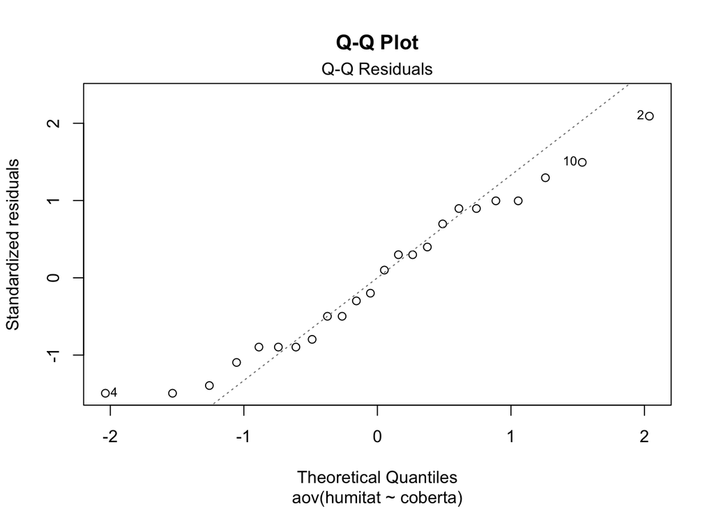

```r
plot(anova_model, which = 2, main = "Q-Q Plot")
```

En el gràfic Q-Q s’observa que, especialment als extrems, els punts s’allunyen de la línia teòrica. No obstant això, a majoria dels residus s’ajusten a la recta, per la qual cosa no hi ha evidència en contra del supòsit de normalitat.

Addicionalment, contrastem la normalitat mitjançant el test de Shapiro-Wilk (en el qual la hipòtesi nul·la és la que afirma que la distribució és normal):

```r
# Residus del model ANOVA
res <- residuals(anova_model)
# Prova de Saphiro-Wilk per normalitat dels residus
sw_test <- shapiro.test(res)
sw_test
```

```
##
##  Shapiro-Wilk normality test
##
## data:  res
## W = 0.95758, p-value = 0.3918
```

NOTA: La prova de Saphiro-Wilk, que és adequada per a mostres de mida petita ($n < 50$), ja que en nostre cas, tenim 24 residus (6 mostres per 4 grups). Per a mostres de mida gran es podria utilitzar la prova d’Anderson-Darling.

Amb un p-value de la prova de Shapiro-Wilk de 0.3918, que és superior al nivell de significança de 0.05, no podem rebutjar la hipòtesi nul·la de normalitat dels residus. Això suggereix que els residus es distribueixen de manera aproximadament normal. A més el valor de W de la prova de Shapiro-Wilk és 0.95758, que està relativament a prop de 1, indicant que els residus segueixen una distribució normal.

No hi ha evidència que indiqui que els residus s’allunyen significativament d’una distribució normal, es compleix el supòsit de normalitat dels residus i per tant podem confiar en els resultats de l’ANOVA i les proves post-hoc associades.

**Avaluació del compliment de la constància de la variància (homoscedasticitat)**

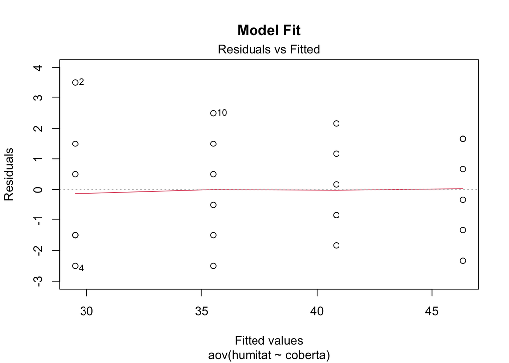

```r
plot(anova_model, which = 1, main = "Model Fit")
```

```r
# Prova de Levene per homogeneïtat de variàncies
levene_test <- leveneTest(humitat ~ coberta, data = data_df)
levene_test
```

```
## Levene's Test for Homogeneity of Variance (center = median)
##       Df F value Pr(>F)
## group  3  0.5719   0.64
##       20
```

Amb un p-value de 0.64, que és superior al nivell de significança de 0.05, no podem rebutjar la hipòtesi nul·la d’homogeneïtat de variàncies entre els grups.

Això suggereix que les variàncies de la humitat del sòl són similars entre els diferents tipus de coberta, complint així el supòsit d’homogeneïtat de variàncies necessari per a l’ANOVA.

# Secció 2. Aplicacions amb Shiny i ètica (3,5 punts)

## Exercici 3 (2,5 punts)

En aquest exercici es proposa el desenvolupament d’una aplicació interactiva amb Shiny per explorar i filtrar el conjunt de dades iris, paquet inclòs a R.

1. (0.25 punts) Carregueu els paquets necessaris per desenvolupar una aplicació Shiny que permeti generar gràfics, mostrar resultats en format taula, i descarregar dades filtrades. Construïu una interfície amb un títol principal adequat i una disposició clara basada en:
   - Una zona lateral amb els controls d’entrada.
   - Una zona principal amb els resultats.
2. (1 punt) La interfície ha d’incloure els elements següents:
   - Un selector per escollir la variable que es representarà a l’eix X del gràfic, que contingui únicament les variables numèriques del conjunt de dades iris.
   - Un segon selector per escollir la variable que es representarà a l’eix Y.
   - Un tercer control per filtrar les observacions segons l’espècie, amb les opcions: totes les observacions, només setosa, només versicolor, només virginica.
   - Una casella de selecció que permeti decidir si es vol mostrar o no
   - Una línia de regressió sobre el diagrama de dispersió.
3. (1 punt) Volem que l’aplicació mostri:
   - Un diagrama de dispersió amb les variables seleccionades als eixos X i Y;
   - punts diferenciats segons l’espècie;
   - un títol dinàmic que indiqui quines variables s’estan comparant;
   - un resum estadístic del conjunt de dades filtrat;
   - la possibilitat de descarregar les dades filtrades en format CSV.
4. (0.25 punts) Dins del document de resposta, expliqueu breument quina és la funció dels elements següents dins d’una aplicació Shiny: ui / server / reactive.

**Resposta:**

```r
#!/usr/bin/env Rscript

library(shiny)
library(ggplot2)
library(dplyr)
library(DT)

ui <- fluidPage(
    titlePanel("Exploració del conjunt de dades iris"),
    sidebarLayout(
        sidebarPanel(
            selectInput("x_var", "Variable a l'eix X:",
                choices = names(iris)[sapply(iris, is.numeric)],
                selected = "Sepal.Length"
            ),
            selectInput("y_var", "Variable a l'eix Y:",
                choices = names(iris)[sapply(iris, is.numeric)],
                selected = "Sepal.Width"
            ),
            selectInput("species_filter", "Filtrar per espècie:",
                choices = c(
                    "Totes les observacions" = "all",
                    "Setosa" = "setosa",
                    "Versicolor" = "versicolor",
                    "Virginica" = "virginica"
                ),
                selected = "all"
            ),
            checkboxInput(
                "show_lm", "Mostrar línia de regressió",
                value = FALSE
            ),
            downloadButton("download_data", "Descarregar dades filtrades")
        ),
        mainPanel(
            plotOutput("scatter_plot"),
            verbatimTextOutput("data_summary"),
            DTOutput("data_table")
        )
    )
)
server <- function(input, output) {
    filtered_data <- reactive({
        if (input$species_filter == "all") {
            iris
        } else {
            iris %>% filter(Species == input$species_filter)
        }
    })
    output$scatter_plot <- renderPlot({
        ggplot(
            filtered_data(),
            aes_string(x = input$x_var, y = input$y_var, color = "Species")
        ) +
            geom_point() +
            labs(title = paste(
                "Diagrama de dispersió:", input$x_var, "vs", input$y_var
            )) +
            theme_minimal() +
            if (input$show_lm) geom_smooth(method = "lm", se = FALSE)
    })
    output$data_summary <- renderPrint({
        summary(filtered_data())
    })
    output$data_table <- renderDT({
        datatable(filtered_data())
    })
    output$download_data <- downloadHandler(
        filename = function() {
            paste("iris_filtrat_", Sys.Date(), ".csv", sep = "")
        },
        content = function(file) {
            write.csv(filtered_data(), file, row.names = FALSE)
        }
    )
}
shinyApp(ui = ui, server = server)
```

El ui defineix la interfície d’usuari i determina com es mostrarà l’aplicació en el navegador, construint l’estructura visual amb elements com botons, menús, gràfics o quadres de text. És una descripció declarativa que especifica l’aparença i l’organització de la pàgina web, i pot estar definida en un fitxer separat o dins del mateix script R. La seva funció és presentar els components interactius que l’usuari manipula i que desencadenen els processos interns de l’aplicació.

El server conté la lògica que s’executa en resposta a les accions de l’usuari, gestionant càlculs, filtratges, generació de gràfics, resums i qualsevol altra operació necessària. És el motor de l’aplicació, responsable de processar les dades i retornar resultats actualitzats a la interfície. Cada vegada que l’usuari modifica un input, el server executa el codi corresponent per mantenir l’aplicació coherent i funcional.

Les expressions reactive encapsulen càlculs que depenen d’inputs i que es tornen a executar automàticament quan aquests inputs canvien, permetent que l’aplicació sigui realment interactiva. Aquest comportament reactiu fa possible que la interfície i els resultats s’actualitzin dinàmicament sense necessitat de reexecutar manualment el codi, garantint una experiència fluida on qualsevol canvi en les dades d’entrada es reflecteix immediatament en les sortides.

## Exercici 4 (1 punt)

En el desenvolupament d’una aplicació interactiva amb Shiny que permet explorar dades biomèdiques i generar visualitzacions i resultats estadístics en temps real, el disseny de l’eina pot influir directament en la interpretació que en fa l’usuari. Elaboreu una resposta argumentada en què analitzeu les responsabilitats ètiques del desenvolupador en relació amb la interpretació dels resultats generats per l’aplicació.

**Resposta:**

En una aplicació Shiny orientada a dades biomèdiques, el desenvolupador té la responsabilitat d’assegurar que la manera com es presenten els resultats no indueixi interpretacions errònies. Quan una eina genera gràfics i estadístics en temps real, l’usuari pot percebre’ls com a veritats objectives, però en realitat estan condicionats per decisions de disseny, selecció de dades i supòsits metodològics. Per això cal garantir claredat, transparència i una comunicació acurada de les limitacions.

La presentació visual pot amplificar o distorsionar la percepció dels resultats. Escales inadequades, comparacions implícites o absència d’indicadors de variabilitat poden portar l’usuari a conclusions precipitades. El desenvolupador ha de vetllar perquè els gràfics siguin interpretables, contextualitzats i honestos sobre la incertesa. Quan es mostren estadístics, cal explicar què signifiquen i què no signifiquen, especialment en un àmbit tan sensible com el biomèdic.

També és essencial evitar que l’aplicació reforci biaixos. Si les dades d’origen no representen tots els grups o si els models incorporen desigualtats preexistents, els resultats poden discriminar sense que l’usuari se n’adoni. El desenvolupador ha de revisar la qualitat i representativitat de les dades, advertir sobre possibles biaixos i evitar que l’eina presenti sortides com a neutres quan no ho són. Quan l’usuari pot filtrar o seleccionar subconjunts, cal prevenir interpretacions que atribueixin causalitat a simples correlacions.

La responsabilitat també inclou garantir que l’usuari entengui els supòsits dels models. Les decisions algorítmiques no són mai completament objectives: depenen de variables escollides, criteris de preprocessament i mètodes estadístics. Si aquests elements no s’expliquen, l’usuari pot confiar massa en resultats que tenen limitacions importants. El desenvolupador ha de fer visibles aquests supòsits i evitar que l’aplicació presenti els models com a infal·libles o clínicament concloents.

La privacitat és un altre pilar. Les dades biomèdiques són especialment sensibles i poden exposar informació íntima. Encara que l’aplicació treballi amb dades anonimitzades, cal evitar que combinacions de filtres o visualitzacions permetin reidentificar individus. El desenvolupador ha de garantir que no es mostrin identificadors, que no es puguin reconstruir perfils i que l’usuari conegui com es tracten les dades.

També cal considerar l’impacte social i psicològic dels resultats. Una visualització que suggereixi risc elevat o diferències marcades pot generar alarma injustificada si no s’acompanya d’explicacions adequades. El desenvolupador ha de dissenyar l’eina perquè fomenti una lectura crítica i informada, evitant dramatitzacions o simplificacions que puguin afectar la percepció de salut de l’usuari.

Finalment, l’accessibilitat cognitiva és clau. No tots els usuaris tenen formació estadística, i una aplicació biomèdica pot ser utilitzada per perfils molt diversos. El desenvolupador ha de proporcionar explicacions clares, llenguatge entenedor i guies interpretatives que ajudin a comprendre els resultats sense induir a error. L’objectiu és que l’eina empoderi l’usuari, no que el confongui o el porti a conclusions equivocades.

En conjunt, el desenvolupador d’una aplicació Shiny biomèdica assumeix una responsabilitat ètica que va més enllà de la funcionalitat tècnica: ha de garantir interpretacions rigoroses, evitar biaixos, protegir la privacitat, comunicar incerteses i facilitar una comprensió adequada dels resultats.

# Secció 3. Bioconductor i anàlisi genòmic (2 punts)

## Exercici 5 (2 punts)

En aquest exercici es demana simular un conjunt de dades d’expressió gènica i dur a terme una anàlisi diferencial bàsica amb el paquet `DESeq2`.

Es demana:

1. (0.5 punts) Genereu una matriu de comptatges d’expressió gènica amb una distribució de Poisson, amb 1000 gens i 20 mostres. Cal indicar clarament com s’ha construït la matriu i quina estructura tenen files i les columnes.
2. (0.5 punts) Definiu un vector o taula de metadades que diferenciï els dos grups experimentals (control i tractament) i creeu l’objecte `DESeqDataSet` corresponent.
3. (0.5 punts) Executeu l’anàlisi diferencial amb `DESeq2` i obteniu la taula de resultats. Cal mostrar, com a mínim, les variables principals del resultat i explicar breument què representen.
4. (0.5 punts) Representeu un histograma dels p-values i un gràfic de dispersió de `log2FoldChange` versus `-log10(pvalue)`. A continuació, interpreteu breument els resultats obtinguts i comenteu què permet observar cadascun dels gràfics.

```r
# Reproductibilitat
set.seed(123)
# a)
num_genes <- 1000
num_samples <- 20
# Generem una matriu de comptatges amb distribució de Poisson
counts <- matrix(
    rpois(num_genes * num_samples, lambda = 10),
    nrow = num_genes, ncol = num_samples
)
rownames(counts) <- paste0("Gene", 1:num_genes)
colnames(counts) <- paste0("Sample", 1:num_samples)
# Mostrem les dimensions i les primeres files de la matriu de comptatges
dim(counts)
```

```
## [1] 1000   20
```

```r
head(counts)
```

```
##       Sample1 Sample2 Sample3 Sample4 Sample5 Sample6 Sample7 Sample8 Sample9
## Gene1       8       9      12      12      10      13       9      13       9
## Gene2       9      12       9       9      10      13      13       9      15
## Gene3      14      10       6       8       9       8      11      15      11
## Gene4      10      11       9       8      12       8       7       9      10
## Gene5      10      12      10       8      10      11       7       6      17
## Gene6      15       7      10       4       9      10      20      10       6
##       Sample10 Sample11 Sample12 Sample13 Sample14 Sample15 Sample16 Sample17
## Gene1       14        9        5        7       16       11        5        8
## Gene2       12        8        6        6       14        6       13       12
## Gene3       11       11        7        5       11       14        7       10
## Gene4        6       13        9        9        9        9        7        9
## Gene5       14       10        9        4       11        6        3       13
## Gene6       11        6        8        9        7       10       10       11
##       Sample18 Sample19 Sample20
## Gene1       11        8        7
## Gene2       13       14        7
## Gene3        9       15        6
## Gene4        6        8        9
## Gene5        7       11       16
## Gene6       11       13        6
```

La matriu de comptatges té 1000 files (gens) i 20 columnes (mostres). Cada element de la matriu representa el nombre de lectures (comptatges) associades a un gen específic en una mostra determinada, generats a partir d’una distribució de Poisson amb un lambda de 10, el que simula un nivell d’expressió gènica moderat.

El nom de les columnes segueix el format “Sample1”, “Sample2”, …, “Sample20”, mentre que les files estan etiquetades com “Gene1”, “Gene2”, …, “Gene1000”.

```r
# b)
# Vector de metadades per diferenciar els grups experimentals
group <- factor(rep(c("Control", "Treatment"), each = num_samples / 2))
colData <- data.frame(group = group)
rownames(colData) <- colnames(counts)
# Creem l'objecte DESeqDataSet
dds <- DESeqDataSetFromMatrix(
    countData = counts, colData = colData, design = ~group
)
# Estructura de l'objecte DESeqDataSet
dds
```

```
## class: DESeqDataSet
## dim: 1000 20
## metadata(1): version
## assays(1): counts
## rownames(1000): Gene1 Gene2 ... Gene999 Gene1000
## rowData names(0):
## colnames(20): Sample1 Sample2 ... Sample19 Sample20
## colData names(1): group
```

```r
# c)
# Executem l'anàlisi diferencial amb DESeq2
dds <- DESeq(dds)
results <- results(dds)
# Mostrem les variables principals del resultat
head(results)
```

```
## log2 fold change (MLE): group Treatment vs Control
## Wald test p-value: group Treatment vs Control
## DataFrame with 6 rows and 6 columns
##        baseMean log2FoldChange     lfcSE      stat    pvalue      padj
##       <numeric>      <numeric> <numeric> <numeric> <numeric> <numeric>
## Gene1   9.49567     -0.3259851  0.239481 -1.361217  0.173445  0.992804
## Gene2  10.15970     -0.1667334  0.231379 -0.720607  0.471151  0.992804
## Gene3   9.58081     -0.1172206  0.238836 -0.490799  0.623568  0.992804
## Gene4   8.61338     -0.0345508  0.245410 -0.140788  0.888037  0.992804
## Gene5   9.42378     -0.2253461  0.246691 -0.913475  0.360993  0.992804
## Gene6   9.31308     -0.1645214  0.245559 -0.669988  0.502866  0.992804
```

Les variables principals del resultat de `DESeq2` són:

- **baseMean**: La mitjana dels comptatges normalitzats per a cada gen a través de totes les mostres.
- **log2FoldChange**: El logaritme en base 2 del fold change entre els grups de tractament i control. Indica la magnitud i direcció del canvi d’expressió.
- **lfcSE**: L’error estàndard associat al `log2FoldChange`, que reflecteix la incertesa de l’estimació del fold change.
- **stat**: L’estadístic de test que s’utilitza per avaluar la significació de la diferència d’expressió entre els grups.
- **pvalue**: El valor p associat a l’estadístic de test, que indica la probabilitat d’obtenir un resultat tan extrem com el observat sota la hipòtesi nul·la de no diferència d’expressió.
- **padj**: El valor p ajustat per al control de la taxa de falsos positius (FDR), que permet identificar els gens diferencialment expressats tenint en compte les múltiples comparacions.

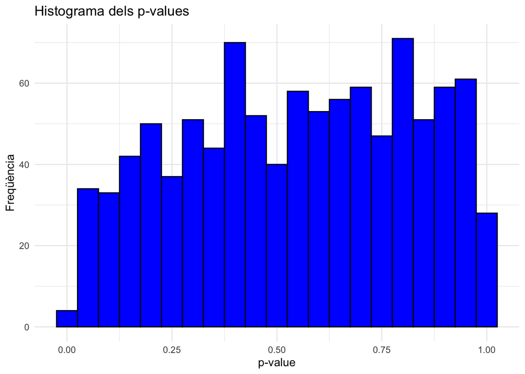

```r
# d)
# Histograma dels p-values
ggplot(as.data.frame(results), aes(x = pvalue)) +
    geom_histogram(binwidth = 0.05, fill = "blue", color = "black") +
    labs(
        title = "Histograma dels p-values",
        x = "p-value",
        y = "Freqüència"
    ) +
    theme_minimal()
```

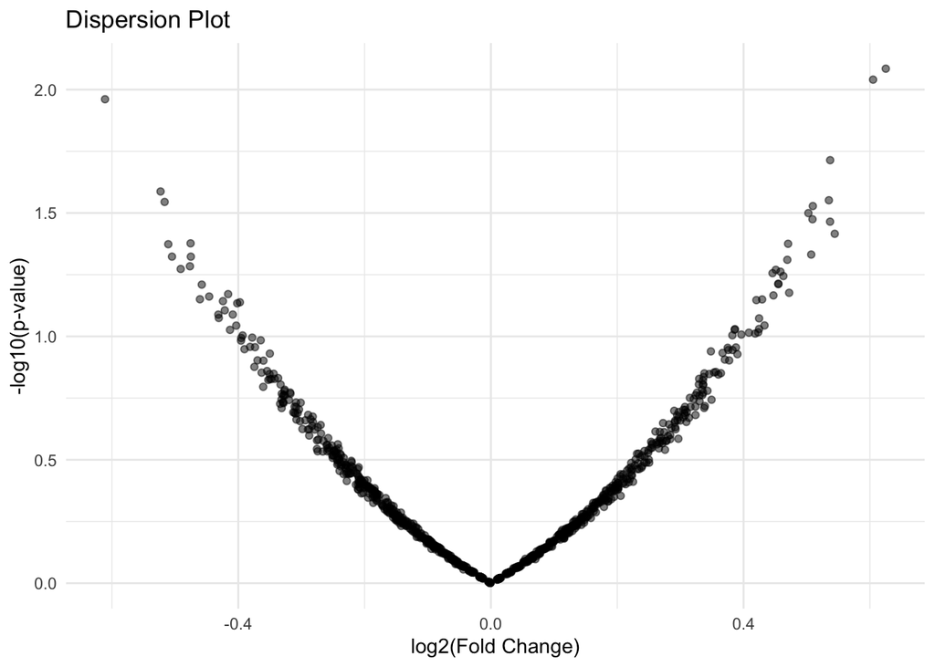

```r
# Gràfic de dispersió de log2FoldChange vs -log10(pvalue)
ggplot(as.data.frame(results), aes(x = log2FoldChange, y = -log10(pvalue))) +
    geom_point(alpha = 0.5) +
    labs(
        title = "Dispersion Plot",
        x = "log2(Fold Change)",
        y = "-log10(p-value)"
    ) +
    theme_minimal()
```

Els gràfics reflecteixen exactament el patró esperable quan es treballa amb dades simulades sense diferències reals entre condicions, on tots els gens presenten un padj ≈ 0.99 i que no hi ha gens diferencialment expressats perquè les dades van ser generades de manera aleatòria.

L’histograma mostra una distribució pràcticament uniforme entre 0 i 1. Aquest patró és coherent amb la situació en què la hipòtesi nul·la és certa per a tots els gens, és a dir, no hi ha cap canvi real d’expressió entre Mostra i Control. Quan no hi ha senyal biològic, els p-values no s’acumulen cap a 0 (com passaria si hi hagués gens diferencialment expressats), sinó que es reparteixen de manera homogènia. Això coincideix amb el que s’observa en l’exemple del material didàctic, on tots els p-values ajustats són molt alts i no hi ha cap evidència de significació estadística.

El diagrama de dispersió mostra els punts concentrats al voltant de `log2FoldChange = 0`, amb valors baixos de `-log10(p-value)`. Aquest patró indica que:

Els valors de `log2FoldChange` són petits i els padj són propers a 1, perquè les dades provenen d’una distribució de Poisson idèntica per a totes les mostres. Per tant, el model no pot detectar diferències que no existeixen.

Els gràfics confirmen que no hi ha gens diferencialment expressats, tal com s’espera en un conjunt de dades generat aleatòriament. Tant l’histograma com el diagrama de dispersió són coherents amb els resultats numèrics, on tots els valors ajustats són alts i no hi ha cap evidència de canvis d’expressió.